# Project 3 - Obianuju Igbokwe

## Problem statement (Term Deposit Sale) - By Obianuju Igbokwe

### Goal:

Using the data collected from existing customers, build a model that will help the marketing team identify potential customers who are relatively more likely to subscribe term deposit and thus increase their hit ratio.

```python
import pandas as pd
import numpy as np

import scipy as sp
import statistics
import matplotlib.pyplot as plt
%matplotlib inline
import seaborn as sns


from sklearn.model_selection import train_test_split
from sklearn.tree import DecisionTreeClassifier
from sklearn import metrics
from sklearn.metrics import accuracy_score, f1_score, precision_score, recall_score, confusion_matrix, roc_auc_score

from os import system
from IPython.display import Image
from sklearn import tree
```

```python
#This is to display multiple output lines from one cell
from IPython.core.interactiveshell import InteractiveShell
InteractiveShell.ast_node_interactivity = "all"
```

### Deliverable 1 : Exploratory data quality report reflecting univariate and multivariate analyses

1. Univariate analysis (12 marks)  
   a. Univariate analysis – data types and description of the independent attributes which should include (name, meaning, range of values observed, central values (mean and median), standard deviation and quartiles, analysis of the body of distributions / tails, missing values, outliers.  
   b. Strategies to address the different data challenges such as data pollution, outlier’s treatment and missing values treatment.  
   c. Please provide comments in jupyter notebook regarding the steps you take and insights drawn from the plots.
2. Multivariate analysis (8 marks)  
   a. Bi-variate analysis between the predictor variables and target column. Comment on your findings in terms of their relationship and degree of relation if any. Presence of leverage points. Visualize the analysis using boxplots and pair plots, histograms or density curves. Select the most appropriate attributes.  
   b. Please provide comments in jupyter notebook regarding the steps you take and insights drawn from the plots

```python
#Load the "bank-full" csv file and store in a variable, `td`
td = pd.read_csv("bank-full.csv")
print('This shows the first 5 records in the `td` dataframe.')
td.head()
```

```
This shows the first 5 records in the `td` dataframe.
```

|  | age | job | marital | education | default | balance | housing | loan | contact | day | month | duration | campaign | pdays | previous | poutcome | Target |
| --- | --- | --- | --- | --- | --- | --- | --- | --- | --- | --- | --- | --- | --- | --- | --- | --- | --- |
| 0 | 58 | management | married | tertiary | no | 2143 | yes | no | unknown | 5 | may | 261 | 1 | -1 | 0 | unknown | no |
| 1 | 44 | technician | single | secondary | no | 29 | yes | no | unknown | 5 | may | 151 | 1 | -1 | 0 | unknown | no |
| 2 | 33 | entrepreneur | married | secondary | no | 2 | yes | yes | unknown | 5 | may | 76 | 1 | -1 | 0 | unknown | no |
| 3 | 47 | blue-collar | married | unknown | no | 1506 | yes | no | unknown | 5 | may | 92 | 1 | -1 | 0 | unknown | no |
| 4 | 33 | unknown | single | unknown | no | 1 | no | no | unknown | 5 | may | 198 | 1 | -1 | 0 | unknown | no |

```python
# Check for the dimension of the dataframe
td.shape
```

```
(45211, 17)
```

### Description of Attributes

[output not shown]

```python
#Assign the independent variables to `Xvar` and print data types
Xvar = td.drop('Target', axis = 1)
print('Data types of independent variables:')
Xvar.dtypes
#change datatype to categorical where needed.
```

```
Data types of independent variables:
```

```
age           int64
job          object
marital      object
education    object
default      object
balance       int64
housing      object
loan         object
contact      object
day           int64
month        object
duration      int64
campaign      int64
pdays         int64
previous      int64
poutcome     object
dtype: object
```

```python
# Check for the number of missing values in features, if any.
Xvar.isnull().sum()
```

```
age          0
job          0
marital      0
education    0
default      0
balance      0
housing      0
loan         0
contact      0
day          0
month        0
duration     0
campaign     0
pdays        0
previous     0
poutcome     0
dtype: int64
```

```python
print('The first 5 records of independent variables:')
Xvar.head()
```

```
The first 5 records of independent variables:
```

|  | age | job | marital | education | default | balance | housing | loan | contact | day | month | duration | campaign | pdays | previous | poutcome |
| --- | --- | --- | --- | --- | --- | --- | --- | --- | --- | --- | --- | --- | --- | --- | --- | --- |
| 0 | 58 | management | married | tertiary | no | 2143 | yes | no | unknown | 5 | may | 261 | 1 | -1 | 0 | unknown |
| 1 | 44 | technician | single | secondary | no | 29 | yes | no | unknown | 5 | may | 151 | 1 | -1 | 0 | unknown |
| 2 | 33 | entrepreneur | married | secondary | no | 2 | yes | yes | unknown | 5 | may | 76 | 1 | -1 | 0 | unknown |
| 3 | 47 | blue-collar | married | unknown | no | 1506 | yes | no | unknown | 5 | may | 92 | 1 | -1 | 0 | unknown |
| 4 | 33 | unknown | single | unknown | no | 1 | no | no | unknown | 5 | may | 198 | 1 | -1 | 0 | unknown |

```python
Xvar.columns
```

```
Index(['age', 'job', 'marital', 'education', 'default', 'balance', 'housing',
       'loan', 'contact', 'day', 'month', 'duration', 'campaign', 'pdays',
       'previous', 'poutcome'],
      dtype='object')
```

```python
print("Statistical description of the numerical independent variables:")
Xvar.describe().transpose()

print('Observations:')
newline = '\n'
print(f"1. The statistic on the 'pdays' feature shows that at least 75% of the customers have not been contacted yet or {newline} have not been contacted in over 900days. \
{newline}2. The statistic on the 'previous' feature shows that at least 75% of the customers were not contacted before the campaign.")
```

```
Statistical description of the numerical independent variables:
```

|  | count | mean | std | min | 25% | 50% | 75% | max |
| --- | --- | --- | --- | --- | --- | --- | --- | --- |
| age | 45211.0 | 40.936210 | 10.618762 | 18.0 | 33.0 | 39.0 | 48.0 | 95.0 |
| balance | 45211.0 | 1362.272058 | 3044.765829 | -8019.0 | 72.0 | 448.0 | 1428.0 | 102127.0 |
| day | 45211.0 | 15.806419 | 8.322476 | 1.0 | 8.0 | 16.0 | 21.0 | 31.0 |
| duration | 45211.0 | 258.163080 | 257.527812 | 0.0 | 103.0 | 180.0 | 319.0 | 4918.0 |
| campaign | 45211.0 | 2.763841 | 3.098021 | 1.0 | 1.0 | 2.0 | 3.0 | 63.0 |
| pdays | 45211.0 | 40.197828 | 100.128746 | -1.0 | -1.0 | -1.0 | -1.0 | 871.0 |
| previous | 45211.0 | 0.580323 | 2.303441 | 0.0 | 0.0 | 0.0 | 0.0 | 275.0 |

```
Observations:
1. The statistic on the 'pdays' feature shows that at least 75% of the customers have not been contacted yet or
 have not been contacted in over 900days.
2. The statistic on the 'previous' feature shows that at least 75% of the customers were not contacted before the campaign.
```

### Univariate Analysis

```python
# Check for the skewness of the independent variables
Xvar.skew()
print('We see here that:')
print("1. 'age' is moderately skewed to the right.")
print("2. 'balance', 'duration', 'campaign', 'pdays' and 'previous' are heavily skewed to the right.")
```

```
age          0.684818
balance      8.360308
day          0.093079
duration     3.144318
campaign     4.898650
pdays        2.615715
previous    41.846454
dtype: float64
```

```
We see here that:
1. 'age' is moderately skewed to the right.
2. 'balance', 'duration', 'campaign', 'pdays' and 'previous' are heavily skewed to the right.
```

```
The outliers in the independent continuous variables are displayed in the boxplots below:
```

```
To treat outliers, normalise the features
```

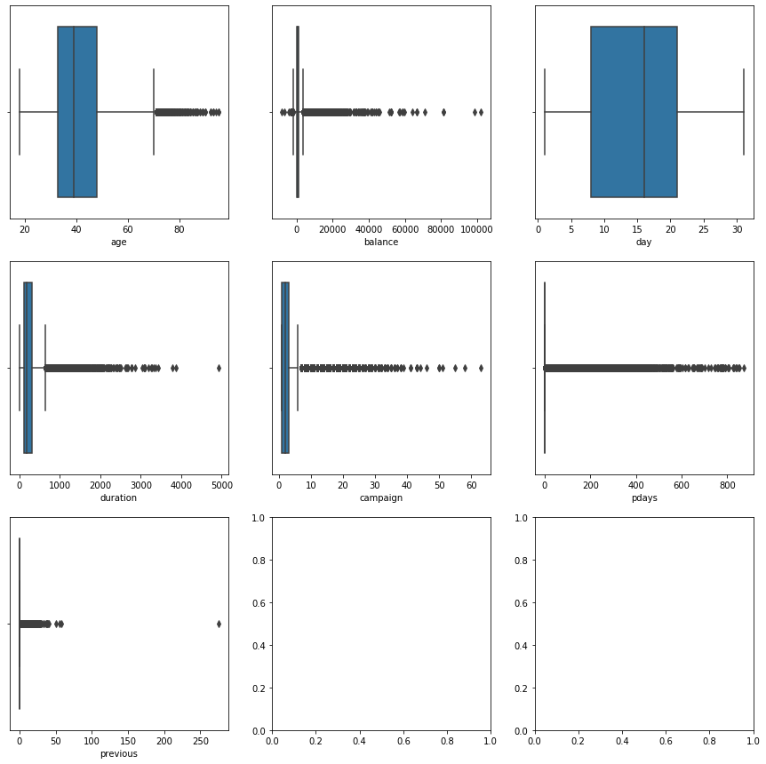

```python
# Check for outliers

#Set up a matplotlib figure
f, axes = plt.subplots(3,3, figsize = (15,15))

print('The outliers in the independent continuous variables are displayed in the boxplots below:')

#Plot boxplots to see outliers
sns.boxplot(Xvar.age, ax=axes[0,0]);
sns.boxplot(Xvar.balance, ax=axes[0,1]);
sns.boxplot(Xvar.day, ax= axes[0,2]);
sns.boxplot(Xvar.duration, ax= axes[1,0]);
sns.boxplot(Xvar.campaign, ax=axes[1,1]);
sns.boxplot(Xvar.pdays, ax=axes[1,2]);
sns.boxplot(Xvar.previous, ax=axes[2,0]);

print('To treat outliers, normalise the features')
```

```
Most of the customers are 32 years old.
The mean age of customers is  41.
```

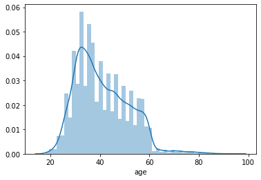

```python
sns.distplot(Xvar['age'])
md = statistics.mode(Xvar['age'])
print(f'Most of the customers are {md} years old. ')
print(f'The mean age of customers is {np.mean(Xvar.age): .0f}.')
```

```python
Xvar['job'].value_counts()

newline="\n"

print(f'There are {Xvar.job.value_counts()[-1]} customers with an unknown job status. \
{newline}This will be treated as its own category because there may be new customers with unknown job status.')
```

```
blue-collar      9732
management       9458
technician       7597
admin.           5171
services         4154
retired          2264
self-employed    1579
entrepreneur     1487
unemployed       1303
housemaid        1240
student           938
unknown           288
Name: job, dtype: int64
```

```
There are 288 customers with an unknown job status.
This will be treated as its own category because there may be new customers with unknown job status.
```

```python
Xvar['marital'].value_counts()
print("This feature looks good with no irregularities.")
```

```
married     27214
single      12790
divorced     5207
Name: marital, dtype: int64
```

```
This feature looks good with no irregularities.
```

```python
Xvar['education'].value_counts()
newline="\n"
print(f"There are {Xvar.education.value_counts()[2]} customers with an unknown education level.\
{newline}Rather than assume their education status is 'secondary', it will be treated as its own category. ")
```

```
secondary    23202
tertiary     13301
primary       6851
unknown       1857
Name: education, dtype: int64
```

[output not shown]

```python
Xvar['default'].value_counts()

print("The 'default' feature looks clean.")
```

```
no     44396
yes      815
Name: default, dtype: int64
```

```
The 'default' feature looks clean.
```

```
The 'balance' feature has a high positive skew of  8.36, but will be left as is because
account balances will always vary depending on the customer.
```

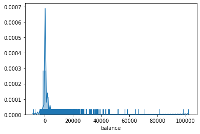

```python
sns.distplot(Xvar.balance, rug=True)

newline="\n"
print(f"The 'balance' feature has a high positive skew of {Xvar.balance.skew(): .2f}, but will be left as is because \
{newline}account balances will always vary depending on the customer.")
```

```python
Xvar['housing'].value_counts()
print("The 'housing' feature looks clean.")
```

```
yes    25130
no     20081
Name: housing, dtype: int64
```

```
The 'housing' feature looks clean.
```

```python
Xvar['loan'].value_counts()
print("The 'loan' feature looks clean.")
```

```
no     37967
yes     7244
Name: loan, dtype: int64
```

```
The 'loan' feature looks clean.
```

```python
Xvar['contact'].value_counts()
newline='\n'
print(f"There are {Xvar.contact.value_counts()[1]} customers that cannot be reached via telephone or cellphone.")
print("")
# Does this make sense? #Can they be reached via email/post/social media, but we do not have that information?

print(f"We will treat the 'unknown' feature as its own category because there may be some other way of reaching out to these \
{newline}customers (via email/post/social media), but that is not stated here.")
```

```
cellular     29285
unknown      13020
telephone     2906
Name: contact, dtype: int64
```

```
There are 13020 customers that cannot be reached via telephone or cellphone.

We will treat the 'unknown' feature as its own category because there may be some other way of reaching out to these
customers (via email/post/social media), but that is not stated here.
```

```python
Xvar['day'].value_counts()
print("The dates have no irregularities.")
# Restructure this category
```

```
20    2752
18    2308
21    2026
17    1939
6     1932
5     1910
14    1848
8     1842
28    1830
7     1817
19    1757
29    1745
15    1703
12    1603
13    1585
```

[output cut: 17 more lines]

```
The dates have no irregularities.
```

```python
Xvar['month'].value_counts()
print("There are no irregularities found in the 'month' feature.")
```

```
may    13766
jul     6895
aug     6247
jun     5341
nov     3970
apr     2932
feb     2649
jan     1403
oct      738
sep      579
mar      477
dec      214
Name: month, dtype: int64
```

```
There are no irregularities found in the 'month' feature.
```

```
The feature, 'duration', has a positive skew of  3.14, but will be left as is
because duration of calls may vary per customer.
```

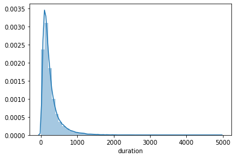

```python
sns.distplot(Xvar['duration'])
newline = '\n'
print(f"The feature, 'duration', has a positive skew of {Xvar.duration.skew(): .2f}, but will be left as is \
{newline}because duration of calls may vary per customer.")
```

```python
Xvar['campaign'].value_counts()
print("The number of categores are too much, they will be reconstructed to 3 categories.")
```

```
1     17544
2     12505
3      5521
4      3522
5      1764
6      1291
7       735
8       540
9       327
10      266
11      201
12      155
13      133
14       93
15       84
```

[output cut: 34 more lines]

```
The number of categores are too much, they will be reconstructed to 3 categories.
```

```python
Xvar.pdays.value_counts()
print("At least 75% of the customers were not contacted or had been contacted in over 900 days after a previous campaign.")
# Check in bivariate analysis with the Target variable.
```

```
-1      36954
 182      167
 92       147
 183      126
 91       126
        ...
 749        1
 717        1
 589        1
 493        1
 32         1
Name: pdays, Length: 559, dtype: int64
```

```
At least 75% of the customers were not contacted or had been contacted in over 900 days after a previous campaign.
```

```python
# Check for unique values for 'pdays'
Xvar.pdays.value_counts().unique()
```

```
array([36954,   167,   147,   126,   117,    99,    85,    77,    74,
          73,    72,    71,    68,    65,    64,    60,    57,    55,
          54,    51,    49,    48,    47,    46,    45,    44,    43,
          42,    40,    38,    37,    36,    35,    34,    33,    32,
          31,    30,    29,    28,    27,    26,    25,    24,    23,
          22,    21,    20,    19,    18,    17,    16,    15,    14,
          13,    12,    11,    10,     9,     8,     7,     6,     5,
           4,     3,     2,     1], dtype=int64)
```

```python
Xvar.previous.value_counts()
print("At least 75% of costumers were not contacted before this campaign, for this client.")
# Check bivariate analysis with the Target variable
```

```
0      36954
1       2772
2       2106
3       1142
4        714
5        459
6        277
7        205
8        129
9         92
10        67
11        65
12        44
13        38
15        20
```

[output cut: 27 more lines]

```
At least 75% of costumers were not contacted before this campaign, for this client.
```

```python
# Check for unique values for 'previous' feature.
Xvar.previous.value_counts().unique()
```

```
array([36954,  2772,  2106,  1142,   714,   459,   277,   205,   129,
          92,    67,    65,    44,    38,    20,    19,    15,    13,
          11,     8,     6,     5,     4,     3,     2,     1],
      dtype=int64)
```

```python
Xvar.poutcome.value_counts()
print("The unknown values will be treated as their own category.")
```

```
unknown    36959
failure     4901
other       1840
success     1511
Name: poutcome, dtype: int64
```

```
The unknown values will be treated as their own category.
```